# Suport Vector Regression Machine - SVRM

Comparando com outros modelos

Autor

Prof. Dr. Pedro Rafael D. Marinho

Data de Publicação

27 de julho de 2023

## 1 Carregando bibliotecas necessárias

```r
library(tidymodels)
library(tidyverse)
library(GGally)
library(skimr)

# Resolvendo possíveis conflitos entre o tidymodels e outras bibliotecas
tidymodels::tidymodels_prefer()
```

## 2 Importando a base de dados

Utilizando os dados de vinho vermelho🍷, disponíveis [aqui](https://www.kaggle.com/datasets/uciml/red-wine-quality-cortez-et-al-2009), faça uma pequena análise exploratória dos dados. No [link](https://www.kaggle.com/datasets/uciml/red-wine-quality-cortez-et-al-2009) do Kaggle você consegue uma explicação sobre o que significa cada uma das variáveis.

Os dados, no meu caso, estão no diretório `"../dados/winequality-red.csv"`. Você deverá alterar o *path* para o diretório encontra-se a base que deverá ser obtida no link acima.

```r
dados <- readr::read_csv(file = "../dados/winequality-red.csv")
```

## 3 Uma exploração rápida dos dados

É sempre importante olhar os dados antes de tentar modelar. Uma análise exploratória sempre será útil para identificarmos possíveis inconsistências.

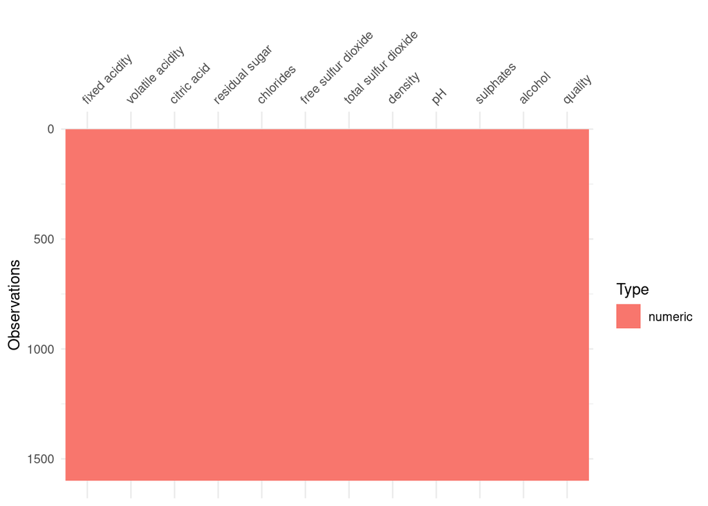

```r
visdat::vis_dat(dados)
```

O gráfico acima mostra que temos uma base de dados sem informações faltantes e todas as *features* presentes na base são numéricas. É uma situação confortável, haja vista que, aqui, não precisaremos nos preocupar com imputação de dados faltantes.

Um resumo dos dados poderá ser obtido utilizando a função `glimpse` do pacote **dplyr** que é carregado com a biblioteca **tidyverse** de R.

```r
dados |>
  dplyr::glimpse()
```

```
Rows: 1,599
Columns: 12
$ `fixed acidity`        <dbl> 7.4, 7.8, 7.8, 11.2, 7.4, 7.4, 7.9, 7.3, 7.8, 7…
$ `volatile acidity`     <dbl> 0.700, 0.880, 0.760, 0.280, 0.700, 0.660, 0.600…
$ `citric acid`          <dbl> 0.00, 0.00, 0.04, 0.56, 0.00, 0.00, 0.06, 0.00,…
$ `residual sugar`       <dbl> 1.9, 2.6, 2.3, 1.9, 1.9, 1.8, 1.6, 1.2, 2.0, 6.…
$ chlorides              <dbl> 0.076, 0.098, 0.092, 0.075, 0.076, 0.075, 0.069…
$ `free sulfur dioxide`  <dbl> 11, 25, 15, 17, 11, 13, 15, 15, 9, 17, 15, 17, …
$ `total sulfur dioxide` <dbl> 34, 67, 54, 60, 34, 40, 59, 21, 18, 102, 65, 10…
$ density                <dbl> 0.9978, 0.9968, 0.9970, 0.9980, 0.9978, 0.9978,…
$ pH                     <dbl> 3.51, 3.20, 3.26, 3.16, 3.51, 3.51, 3.30, 3.39,…
$ sulphates              <dbl> 0.56, 0.68, 0.65, 0.58, 0.56, 0.56, 0.46, 0.47,…
$ alcohol                <dbl> 9.4, 9.8, 9.8, 9.8, 9.4, 9.4, 9.4, 10.0, 9.5, 1…
$ quality                <dbl> 5, 5, 5, 6, 5, 5, 5, 7, 7, 5, 5, 5, 5, 5, 5, 5,…
```

É possível todas as correlações entre todas as variáveis da base, com a função `data_vis_cor`. Um gráfico útil com as correlações poderá ser obtido usando a função `vis_cor`, conforme abaixo:

```r
visdat::data_vis_cor(dados)
```

```
# A tibble: 144 × 3
   row_1         row_2                  value
   <chr>         <chr>                  <dbl>
 1 fixed acidity fixed acidity         1
 2 fixed acidity volatile acidity     -0.256
 3 fixed acidity citric acid           0.672
 4 fixed acidity residual sugar        0.115
 5 fixed acidity chlorides             0.0937
 6 fixed acidity free sulfur dioxide  -0.154
 7 fixed acidity total sulfur dioxide -0.113
 8 fixed acidity density               0.668
 9 fixed acidity pH                   -0.683
10 fixed acidity sulphates             0.183
# ℹ 134 more rows
```

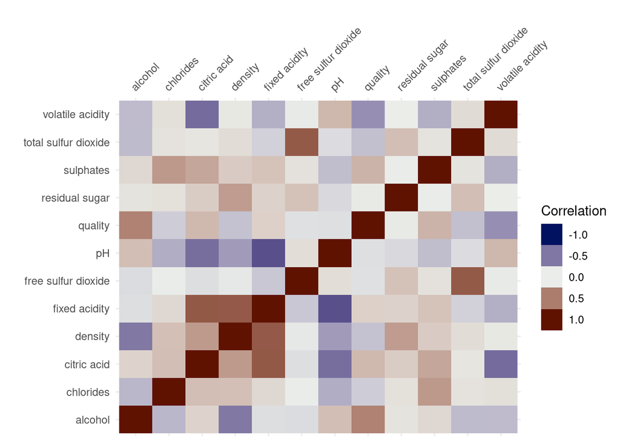

```r
visdat::vis_cor(dados)
```

Um gráfico de scatterplot para as variáveis numéricas poderá ser útil. Você poderá fazer isso, usando a função `ggcatmat` do pacote [GGally](https://ggobi.github.io/ggally/).

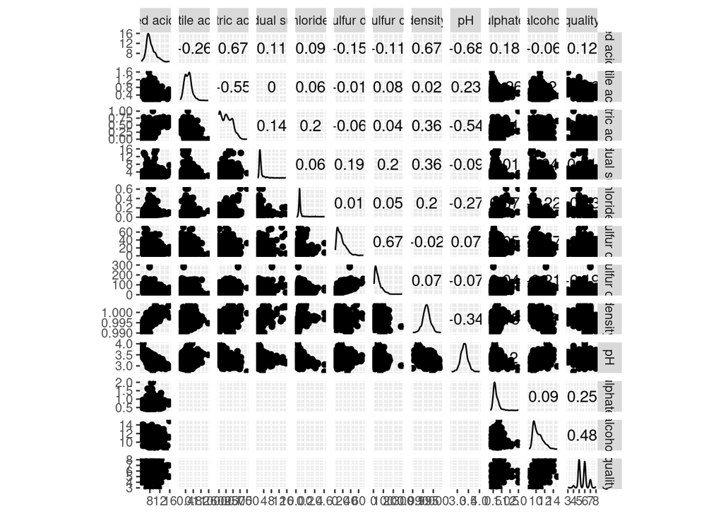

```r
dados |>
  GGally::ggscatmat()
```

As bibliotecas **GGally** e **skimr** também possuem funções úteis que podem nos auxiliar no processo de exploração dos dados.

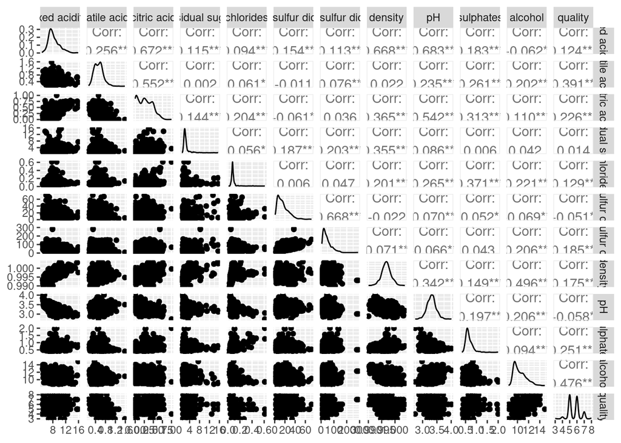

```r
dados |>
  GGally::ggpairs()
```

```r
dados |>
  skimr::skim()
```

Data summary

| Name | dados |
| --- | --- |
| Number of rows | 1599 |
| Number of columns | 12 |
| _______________________ |  |
| Column type frequency: |  |
| numeric | 12 |
| ________________________ |  |
| Group variables | None |

**Variable type: numeric**

| skim_variable | n_missing | complete_rate | mean | sd | p0 | p25 | p50 | p75 | p100 | hist |
| --- | --- | --- | --- | --- | --- | --- | --- | --- | --- | --- |
| fixed acidity | 0 | 1 | 8.32 | 1.74 | 4.60 | 7.10 | 7.90 | 9.20 | 15.90 | ▂▇▂▁▁ |
| volatile acidity | 0 | 1 | 0.53 | 0.18 | 0.12 | 0.39 | 0.52 | 0.64 | 1.58 | ▅▇▂▁▁ |
| citric acid | 0 | 1 | 0.27 | 0.19 | 0.00 | 0.09 | 0.26 | 0.42 | 1.00 | ▇▆▅▁▁ |
| residual sugar | 0 | 1 | 2.54 | 1.41 | 0.90 | 1.90 | 2.20 | 2.60 | 15.50 | ▇▁▁▁▁ |
| chlorides | 0 | 1 | 0.09 | 0.05 | 0.01 | 0.07 | 0.08 | 0.09 | 0.61 | ▇▁▁▁▁ |
| free sulfur dioxide | 0 | 1 | 15.87 | 10.46 | 1.00 | 7.00 | 14.00 | 21.00 | 72.00 | ▇▅▁▁▁ |
| total sulfur dioxide | 0 | 1 | 46.47 | 32.90 | 6.00 | 22.00 | 38.00 | 62.00 | 289.00 | ▇▂▁▁▁ |
| density | 0 | 1 | 1.00 | 0.00 | 0.99 | 1.00 | 1.00 | 1.00 | 1.00 | ▁▃▇▂▁ |
| pH | 0 | 1 | 3.31 | 0.15 | 2.74 | 3.21 | 3.31 | 3.40 | 4.01 | ▁▅▇▂▁ |
| sulphates | 0 | 1 | 0.66 | 0.17 | 0.33 | 0.55 | 0.62 | 0.73 | 2.00 | ▇▅▁▁▁ |
| alcohol | 0 | 1 | 10.42 | 1.07 | 8.40 | 9.50 | 10.20 | 11.10 | 14.90 | ▇▇▃▁▁ |
| quality | 0 | 1 | 5.64 | 0.81 | 3.00 | 5.00 | 6.00 | 6.00 | 8.00 | ▁▇▇▂▁ |

## 4 Construindo os workflows dos modelos

Iremos comparar os modelos de regressão linar utilizando *elastic net*, com o método $k$NN e *suport vector regression machine* - SVRM. Buscaremos pelo melhor modelo de cada uma das metodologias consideradas. Posteriormente iremos escolher o melhor modelo entre os melhores de cada uma das classes. A ideia é escolher o melhor modelo que consiga prever melhor a qualidade do vinho, i.e., prever a variável `quality`.

### 4.1 Divisão dos dados

Aqui usaremos as funções `initial_split`, `training` e `testing` para realizar o método *hold-out* (divisão inicial dos dados) em treino e teste. Vamos considerar $80\%$ para treino e $20\%$ para teste. A função `initial_split` irá realizar a divisão, porém, as funções `training` e `testing` são responsáveis para obtermos as tibbles da base de treino e teste, respectivamente.

Aqui, os dados está sendo estratificado pelo *label*, i.e., pela variável `quality` que desejamos prever:

```r
set.seed(0) # Fixando uma semente
divisao_inicial <- rsample::initial_split(dados, prop = 0.8, strata = "quality")
treinamento <- rsample::training(divisao_inicial) # Conjunto de treinamento
teste <- rsample::testing(divisao_inicial) # Conjunto de teste
```

### 4.2 Tratamento dos dados (pré-processamento)

Apesar de não haver muito o que fazer nos dados que estamos utilizando nesse exemplo, em que nosso objetivo aqui é ter uma análise explicativa de como comparar modelos usando o [tidymodels](https://www.tidymodels.org/), iremos utilizar a biblioteca [recipes](https://recipes.tidymodels.org/). Os dados contém apenas variáveis numéricas com todas informações presentes, tornando o problema um pouco mais simples.

```r
receita_1 <-
  treinamento |>
    recipe(formula = quality ~ .) |>
    step_YeoJohnson(all_predictors()) |>
    step_normalize(all_predictors()) |>
    step_zv(all_predictors()) |>
    step_corr(all_predictors())

receita_2 <-
  treinamento |>
    recipe(formula = quality ~ .) |>
    step_YeoJohnson(all_predictors()) |>
    step_normalize(all_predictors())
```

**Como fazemos para observar se nosso pré-processamento funcionou?**

[figure not shown]

Fácil, assim:

```r
receita_1 |>
  prep() |>
  juice()
```

```
# A tibble: 1,278 × 12
   `fixed acidity` `volatile acidity` `citric acid` `residual sugar` chlorides
             <dbl>              <dbl>         <dbl>            <dbl>     <dbl>
 1         -0.446              1.00          -1.52            -0.602   -0.245
 2         -0.162              1.77          -1.52             0.559    0.198
 3         -0.162              1.28          -1.25             0.154    0.0774
 4         -0.446              1.00          -1.52            -0.602   -0.245
 5         -0.446              0.813         -1.52            -0.845   -0.265
 6         -0.0949             0.508         -1.12            -1.42    -0.386
 7         -0.373             -0.0496         0.527            2.10    -0.346
 8         -1.01               0.402         -0.994           -0.845    0.178
 9         -0.373             -0.0496         0.527            2.10    -0.346
10         -0.162              0.560          0.186           -1.42     0.521
# ℹ 1,268 more rows
# ℹ 7 more variables: `free sulfur dioxide` <dbl>,
#   `total sulfur dioxide` <dbl>, density <dbl>, pH <dbl>, sulphates <dbl>,
#   alcohol <dbl>, quality <dbl>
```

A função `prep` estima uma receita de pré-processamento. Algumas funções `step_*` pode conter parâmetros que devem ser estimados. Inclusive, poderemos tunar esses parâmetros com a função `tune` do pacote [tune](https://tune.tidymodels.org/). Por exemplo, se tivessemos interesse em interpolar uma *feature* usando a função `step_ns`, o argumento `deg_free` que refere-se ao grau do polinômio poderia ser “tunado”.

Poderíamos utilizar a função `bake` ao invés da `juice`. A diferença de uma para a outra é que a função `bake` utiliza uma receita já estimada com `prep` e poderá ser aplicada à novos dados. Já a `juice` retorna a tibble com a receita preparada para o conjunto de dados de treinamento, ou ao conjunto de dados ao qual uma receita foi preparada com `prep`. Usando `bake` para o conjunto de dados de treinamento, poderíamos fazer:

```r
receita_1 |>
  prep() |>
  bake(new_data = treinamento)
```

```
# A tibble: 1,278 × 12
   `fixed acidity` `volatile acidity` `citric acid` `residual sugar` chlorides
             <dbl>              <dbl>         <dbl>            <dbl>     <dbl>
 1         -0.446              1.00          -1.52            -0.602   -0.245
 2         -0.162              1.77          -1.52             0.559    0.198
 3         -0.162              1.28          -1.25             0.154    0.0774
 4         -0.446              1.00          -1.52            -0.602   -0.245
 5         -0.446              0.813         -1.52            -0.845   -0.265
 6         -0.0949             0.508         -1.12            -1.42    -0.386
 7         -0.373             -0.0496         0.527            2.10    -0.346
 8         -1.01               0.402         -0.994           -0.845    0.178
 9         -0.373             -0.0496         0.527            2.10    -0.346
10         -0.162              0.560          0.186           -1.42     0.521
# ℹ 1,268 more rows
# ℹ 7 more variables: `free sulfur dioxide` <dbl>,
#   `total sulfur dioxide` <dbl>, density <dbl>, pH <dbl>, sulphates <dbl>,
#   alcohol <dbl>, quality <dbl>
```

### 4.3 Definindo os modelos

O código que segue faz a configuração realiza a configuração dos modelos que serão comparados. O código `tune::tune()` especifica que o respectivo parâmetro de sintonização será obtido no processo de validação cruzada, particularmente, um *grid search*.

```r
modelo_elastic <-
  parsnip::linear_reg(penalty = tune::tune(), mixture = tune::tune()) |>
  parsnip::set_mode("regression") |>
  parsnip::set_engine("glmnet")

modelo_knn <-
  parsnip::nearest_neighbor(
    neighbors = tune::tune(),
    dist_power = tune::tune(),
    weight_func = "gaussian"
  ) |>
  parsnip::set_mode("regression") |>
  parsnip::set_engine("kknn")

modelo_svm <-
  parsnip::svm_rbf(
    cost = tune::tune(),
    rbf_sigma = tune::tune(),
    margin = tune::tune()
  ) |>
  parsnip::set_mode("regression") |>
  parsnip::set_engine("kernlab")
```

### 4.4 Criando o conjunto de validação

Uma vez que temos a divisão dos dados em conjunto de treinamento e conjunto de teste, precisamos construir o conjunto de validação, que necesse caso utilizaremos um $k$-*fold cross-validation*. Lembre-se que a validação cruzada ocorrerá sob a amostra de treinamento e necesso processo, a base de dados de treinamento será dividida em $k$ partes aproximadamente iguais em que trainamos o modelo em $k-1$ e validanos no *fold* restante, em que isso é feito $k$ vezes. Utilizando o conjunto $k-1$ em cada uma das divisões da validação cruzada em que diferentes combinações de hiperparâmetros são experimentadas e avaliada no conjunto de validação em cada divisão da validação cruzada.

O código que segue, em que utiliza a função `vfold_cv` da biblioteca [rsample](https://rsample.tidymodels.org/) apenas cria a validação cruzada. Nesse caso, a validação será estratificada considerando a o *label* `quality` (qualidade do vinho), assim como foi feito na divisão inicial no *hold-out* (divisão inicial dos dados).

Utilizaremos $k=8$:

```r
validacao_cruzada <-
  treinamento |>
  rsample::vfold_cv(v = 8L, strata = quality)
```

### 4.5 Criando um *workflow* completo

Aqui criaremos um *workflow* completo com todos modelos a serem comparados. Chamaremos ele de `wf_todos`:

```r
wf_todos <-
  workflow_set(
    preproc = list(receita_1, receita_2),
    models = list(
      knn_fit = modelo_knn,
      elastic_fit = modelo_elastic,
      svm_fit = modelo_svm
    ),
    cross = TRUE
  )
```

Podemos manipular alguns argumentos que controlam aspectos da pesquisa em grade (*grid search*).. Fazemos isso com o uso da função `control_grid` da biblioteca [parsnip](https://parsnip.tidymodels.org/). Por exemplo, podemos informar que desejamos paralelizar essa pesquisa, passando o argumento `parallel_over = "resamples"`. Podemos também salvar as predições para cada um dos modelos especificando o argumento `save_pred = TRUE`. Se desejarmos anexar à saída o *workflow*, fazemos `save_workflow = TRUE`.

Assim, criaremos o objeto `controle_grid`, para que possamos passar a função `workflow_map` posteriormente. Tem-se:

```r
controle_grid <- control_grid(
  save_pred = TRUE,
  save_workflow = TRUE,
  parallel_over = "resamples"
)
```

### 4.6 Trainando o modelo

Nessa etapa iremos treinar o modelo usando a função `workflow_map` do pacote [workflow](https://workflows.tidymodels.org/). Temos então:

```r
treino <-
  wf_todos |>
  workflow_map(
    resamples = validacao_cruzada,
    grid = 20L,
    control = controle_grid
  )
```

A função `autoplot` do pacote **ggplot2** é útil para que possamos visualizar o desempenho de cada um dos modelos considerando a métrica do EQM. Isso é feito da seguinte forma:

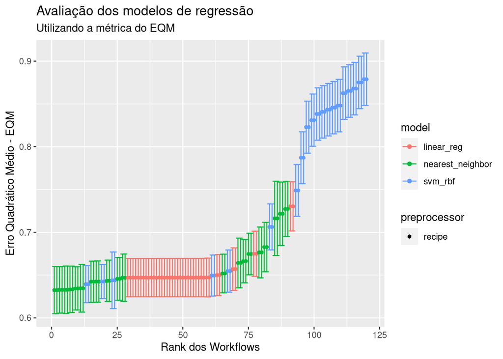

```r
autoplot(treino, metric = "rmse") +
  labs(
    title = "Avaliação dos modelos de regressão",
    subtitle = "Utilizando a métrica do EQM"
  ) +
  xlab("Rank dos Workflows") +
  ylab("Erro Quadrático Médio - EQM")
```

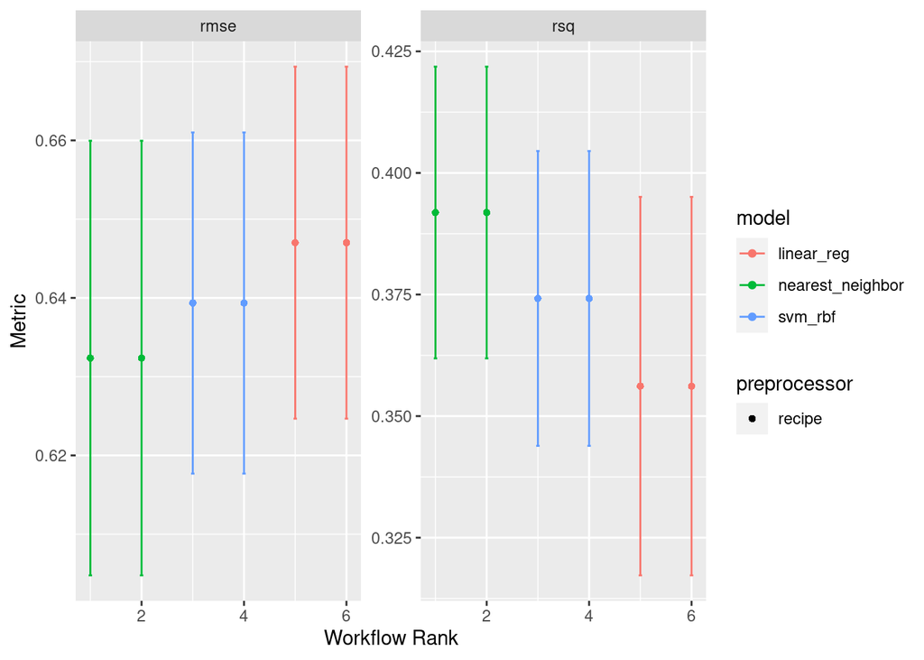

```r
melhores <-
  treino |>
  rank_results(select_best = TRUE, rank_metric = "rmse")

autoplot(treino, select_best = TRUE)
```

Vamos agora selecionar o melhor modelo dentre os modelos comparados. Isso não quer dizer que o modelo seja bom para resolver o problema em questão. Para ver um rank e saber qual modelo e receita foram as melhores, fazemos:

```r
treino |>
  rank_results()
```

```
# A tibble: 240 × 9
   wflow_id         .config .metric  mean std_err     n preprocessor
model  rank
   <chr>            <chr>   <chr>   <dbl>
<dbl> <int> <chr>        <chr> <int>
 1 recipe_2_knn_fit Prepro… rmse    0.632  0.0168     8 recipe
near…     1
 2 recipe_2_knn_fit Prepro… rsq     0.392  0.0182     8 recipe
near…     1
 3 recipe_1_knn_fit Prepro… rmse    0.632  0.0168     8 recipe
near…     2
 4 recipe_1_knn_fit Prepro… rsq     0.392  0.0182     8 recipe
near…     2
 5 recipe_1_knn_fit Prepro… rmse    0.633  0.0165     8 recipe
near…     3
 6 recipe_1_knn_fit Prepro… rsq     0.391  0.0174     8 recipe
near…     3
 7 recipe_2_knn_fit Prepro… rmse    0.633  0.0165     8 recipe
near…     4
 8 recipe_2_knn_fit Prepro… rsq     0.391  0.0174     8 recipe
near…     4
 9 recipe_2_knn_fit Prepro… rmse    0.633  0.0169     8 recipe
near…     5
10 recipe_2_knn_fit Prepro… rsq     0.390  0.0188     8 recipe
near…     5
# ℹ 230 more rows
```

```r
melhor_modelo <-
  treino |>
  extract_workflow_set_result(id = "recipe_1_knn_fit") |>
  select_best(metric = "rmse")

melhor_modelo
```

```
# A tibble: 1 × 3
  neighbors dist_power .config
      <int>      <dbl> <chr>
1        12       1.47 Preprocessor1_Model15
```

### 4.7 Avaliação final do melhor modelo

Após a escolha do melhor modelo e da estimação de seus hiperparâmetros, nesse caso, o modelo $k$NN com $k = 12$ e `dist_power \approx 1.47`, precisamos testar o desempenho do modelo final segundo a base de dados de teste. Para tanto, utilizamos a função `last_fit` do pacote [tune](https://tune.tidymodels.org/reference/last_fit.html). Temos que:

```r
wf_final <-
  treino |>
  extract_workflow(id = "recipe_1_knn_fit") |>
  finalize_workflow(melhor_modelo)

teste <-
  wf_final |>
  last_fit(split = divisao_inicial)

teste$.metrics
```

```
[[1]]
# A tibble: 2 × 4
  .metric .estimator .estimate .config
  <chr>   <chr>          <dbl> <chr>
1 rmse    standard       0.629 Preprocessor1_Model1
2 rsq     standard       0.405 Preprocessor1_Model1
```

Agora que temos os hiperparâmetros estimados e temos uma boa estimativa do risco preditivo real do modelo final selecionado, poderemos preceder com um ajuste final, com toda a base de dados (treinamento + teste).

```r
modelo_final <-
  wf_final |>
  fit(dados)
```

### 4.8 Salvando o modelo

Depois que temos o modelo finalizado, podemos ter alguns interesses de como utilizar o resultado, i.e., o modelo treinado. Entre alguns motivos, posso citar:

1. Salvar o modelo para uso no futuro, sem ter que retreinar;
2. Distribuir o modelo para que outras pessoas possam experimentar, sem terem que executar seu script R e retreinar o modelo;
3. Introduzir seu modelo treinado em uma API que irá consumir os resultados, i.e., consumir as previsões do modelo.

Nessas situações, é conveniente salvar o modelo em um arquivo serializado (*R Data Serialization*). Tais arquivos possuem a extensão `.rds`. Devemos fazer:

```r
# Salvando o modelo em um arquivo serializado
saveRDS(modelo_final, file = "modelo_final.rds")

# Lendo o arquivo serializado com o modelo final
load(file = "modelo_final.rds")

# Fazendo novas previsões
predict(modelo_final, new_data = novos_dados)
```